# STATS 506 - Problem Set 2

Author

Jiahao Li

GitHub Repository: https://github.com/epter-png/data506-ps02

## Problem 1 - Random Walk with Momentum

### (a) Simulation function

```r
# Simulate a random walk with momentum.
# Inputs: positive integer n; probability p in [0, 1].
# Output: named vector of final x and y coordinates.
momentum_walk <- function(n, p) {
  if (!is.numeric(n) || length(n) != 1L ||
      is.na(n) || !is.finite(n) || n < 1 || n != floor(n)) {
    stop("n must be a positive integer.")
  }

  if (!is.numeric(p) || length(p) != 1L ||
      is.na(p) || !is.finite(p) || p < 0 || p > 1) {
    stop("p must be a number between 0 and 1.")
  }

  directions <- rbind(
    right = c(1, 0),
    left = c(-1, 0),
    up = c(0, 1),
    down = c(0, -1)
  )

  direction <- sample.int(4, 1)
  position <- directions[direction, ]

  if (n > 1) {
    for (i in seq_len(n - 1)) {
      if (runif(1) >= p) {
        direction <- sample.int(4, 1)
      }
      position <- position + directions[direction, ]
    }
  }

  setNames(position, c("x", "y"))
}

set.seed(506)
momentum_walk(10, 0.6)
```

```
 x  y
-2  0
```

```r
momentum_walk(1000, 0.6)
```

```
  x   y
-16 -32
```

I chose the first direction randomly, giving each of the four directions the same probability. For later steps, I kept the previous direction with probability p. Otherwise, I randomly chose from all four directions, so the particle could still pick the same direction. My function also checks that n is a positive integer and p is between 0 and 1.

### (b) Two implementations

```r
# Loop version of momentum_walk().
# Inputs: positive integer n; probability p in [0, 1].
# Output: final x and y coordinates.
momentum_walk1 <- function(n, p) {
  momentum_walk(n, p)
}

# Apply version of momentum_walk().
# Inputs: positive integer n; probability p in [0, 1].
# Output: final x and y coordinates.
momentum_walk2 <- function(n, p) {
  if (!is.numeric(n) || length(n) != 1L ||
      is.na(n) || !is.finite(n) || n < 1 || n != floor(n)) {
    stop("n must be a positive integer.")
  }

  if (!is.numeric(p) || length(p) != 1L ||
      is.na(p) || !is.finite(p) || p < 0 || p > 1) {
    stop("p must be a number between 0 and 1.")
  }

  directions <- rbind(
    right = c(1, 0),
    left = c(-1, 0),
    up = c(0, 1),
    down = c(0, -1)
  )

  direction <- sample.int(4, 1)
  first_step <- directions[direction, ]

  if (n == 1) {
    return(setNames(first_step, c("x", "y")))
  }

  steps <- vapply(seq_len(n - 1), function(i) {
    if (runif(1) >= p) {
      direction <<- sample.int(4, 1)
    }
    directions[direction, ]
  }, numeric(2))

  setNames(first_step + rowSums(steps), c("x", "y"))
}

set.seed(506)
momentum_walk1(10, 0.6)
```

```
 x  y
-2  0
```

```r
momentum_walk2(10, 0.6)
```

```
 x  y
-1  1
```

```r
momentum_walk1(1000, 0.6)
```

```
  x   y
-22 -34
```

```r
momentum_walk2(1000, 0.6)
```

```
  x   y
-91 -55
```

The loop version updates the direction and position at each step. The second version uses vapply() to generate the steps, then adds them together with rowSums(). The <<- operator preserves the previous direction between calls, allowing consecutive steps to depend on each other. Both versions simulate the same process, although their results may differ because of random variation.

### (c) Reproducibility

```r
set.seed(506)
result10_a <- momentum_walk1(10, 0.6)

set.seed(506)
result10_b <- momentum_walk1(10, 0.6)

rbind(first_run = result10_a, second_run = result10_b)
```

```
            x y
first_run  -2 0
second_run -2 0
```

```r
identical(result10_a, result10_b)
```

```
[1] TRUE
```

```r
set.seed(506)
result1000_a <- momentum_walk1(1000, 0.6)

set.seed(506)
result1000_b <- momentum_walk1(1000, 0.6)

rbind(first_run = result1000_a, second_run = result1000_b)
```

```
             x   y
first_run  -14 -30
second_run -14 -30
```

```r
identical(result1000_a, result1000_b)
```

```
[1] TRUE
```

For both n = 10 and n = 1000, the two runs produce identical final positions, and identical() returns TRUE. Setting the same seed before each run resets the random-number generator to the same starting state. This makes the simulation reproducible, even though the walk itself is random.

### (d) Does momentum matter?

```r
set.seed(506)

p_values <- c(0, 0.5, 0.9)

positions <- vapply(
  p_values,
  function(p) momentum_walk1(1000, p),
  numeric(2)
)

distance_table <- data.frame(
  p = p_values,
  x = positions[1, ],
  y = positions[2, ],
  distance = sqrt(colSums(positions^2))
)

knitr::kable(distance_table, digits = 3, row.names = FALSE)
```

| p | x | y | distance |
| --- | --- | --- | --- |
| 0.0 | 3 | -23 | 23.195 |
| 0.5 | -62 | 6 | 62.290 |
| 0.9 | -25 | -155 | 157.003 |

The final distances are 23.195, 62.290, and 157.003 for p = 0, 0.5, and 0.9, respectively. In these simulations, the distance increases as momentum increases. This makes sense because higher momentum encourages consecutive steps in the same direction. However, one walk for each value of p is not enough to establish a general trend, since the results depend on random variation.

### (e) Monte Carlo simulation

```r
set.seed(506)

momentum_values <- c(0, 0.25, 0.5, 0.75, 0.9)

mean_distances <- vapply(momentum_values, function(p) {
  distances <- replicate(1000, {
    position <- momentum_walk1(1000, p)
    sqrt(sum(position^2))
  })
  mean(distances)
}, numeric(1))

mc_table <- data.frame(
  p = momentum_values,
  mean_distance = mean_distances
)

knitr::kable(mc_table, digits = 3, row.names = FALSE)
```

| p | mean_distance |
| --- | --- |
| 0.00 | 27.754 |
| 0.25 | 36.243 |
| 0.50 | 48.418 |
| 0.75 | 75.695 |
| 0.90 | 122.895 |

Based on 1,000 walks for each value of p, the mean final distance increases from 27.754 at p = 0 to 122.895 at p = 0.9. The increase is consistent across all five values of p. These results suggest that higher momentum leads to a greater average distance from the starting point, since steps are more likely to continue in the same direction.

### (f) Computational performance

```r
library(microbenchmark)

set.seed(506)
benchmark_small <- microbenchmark(
  loop = momentum_walk1(1000, 0.6),
  apply = momentum_walk2(1000, 0.6),
  times = 20L
)

set.seed(506)
benchmark_large <- microbenchmark(
  loop = momentum_walk1(100000, 0.6),
  apply = momentum_walk2(100000, 0.6),
  times = 20L
)

knitr::kable(
  summary(benchmark_small, unit = "ms"),
  digits = 3,
  caption = "Execution times in milliseconds: n = 1000"
)
```

Execution times in milliseconds: n = 1000

| expr | min | lq | mean | median | uq | max | neval |
| --- | --- | --- | --- | --- | --- | --- | --- |
| loop | 1.363 | 1.448 | 1.539 | 1.472 | 1.547 | 2.454 | 20 |
| apply | 1.861 | 1.914 | 2.071 | 2.003 | 2.103 | 2.721 | 20 |

```r
knitr::kable(
  summary(benchmark_large, unit = "ms"),
  digits = 3,
  caption = "Execution times in milliseconds: n = 100000"
)
```

Execution times in milliseconds: n = 100000

| expr | min | lq | mean | median | uq | max | neval |
| --- | --- | --- | --- | --- | --- | --- | --- |
| loop | 148.013 | 148.889 | 151.223 | 149.385 | 150.401 | 169.569 | 20 |
| apply | 193.211 | 193.878 | 196.158 | 194.976 | 196.802 | 215.017 | 20 |

## Problem 2 - Campus Bus Arrivals

```r
set.seed(506)

n_days <- 10000

daily_passengers <-
  rpois(n_days, lambda = 3 * 4) +
  rnorm(n_days, mean = 45, sd = sqrt(16)) +
  rpois(n_days, lambda = 6 * 15) +
  rnorm(n_days, mean = 55, sd = sqrt(25)) +
  rpois(n_days, lambda = 6 * 9)

bus_results <- data.frame(
  simulated_mean = mean(daily_passengers),
  theoretical_mean = 3 * 4 + 45 + 6 * 15 + 55 + 6 * 9,
  Monte_Carlo_SE = sd(daily_passengers) / sqrt(n_days)
)

knitr::kable(bus_results, digits = 3, row.names = FALSE)
```

| simulated_mean | theoretical_mean | Monte_Carlo_SE |
| --- | --- | --- |
| 256.097 | 256 | 0.142 |

The simulation estimates an average of 256.097 passengers per day, which is close to the theoretical mean of 256. The Monte Carlo standard error is approximately 0.142. Assuming independent hourly counts, the Poisson counts within each time period can be combined by adding their means. This allows 10,000 daily totals to be simulated using vectorized operations without loops.

## Problem 3 - Linear Regression

### (a) Data preparation and de-identification

```r
youtube <- read.csv(
  "https://raw.githubusercontent.com/rfordatascience/tidytuesday/master/data/2021/2021-03-02/youtube.csv",
  stringsAsFactors = FALSE
)

names(youtube)
```

```
 [1] "year"                      "brand"
 [3] "superbowl_ads_dot_com_url" "youtube_url"
 [5] "funny"                     "show_product_quickly"
 [7] "patriotic"                 "celebrity"
 [9] "danger"                    "animals"
[11] "use_sex"                   "id"
[13] "kind"                      "etag"
[15] "view_count"                "like_count"
[17] "dislike_count"             "favorite_count"
[19] "comment_count"             "published_at"
[21] "title"                     "description"
[23] "thumbnail"                 "channel_title"
[25] "category_id"
```

```r
analysis_vars <- c(
  "year",
  "funny", "show_product_quickly", "patriotic",
  "celebrity", "danger", "animals", "use_sex",
  "view_count", "like_count", "dislike_count",
  "favorite_count", "comment_count"
)

youtube_clean <- youtube[analysis_vars]

setdiff(names(youtube), names(youtube_clean))
```

```
 [1] "brand"                     "superbowl_ads_dot_com_url"
 [3] "youtube_url"               "id"
 [5] "kind"                      "etag"
 [7] "published_at"              "title"
 [9] "description"               "thumbnail"
[11] "channel_title"             "category_id"
```

```r
dim(youtube_clean)
```

```
[1] 247  13
```

After removing identifying information such as brand, title, URLs, channel, and publication details, the dataset contains 247 observations and 13 variables. The remaining variables are the seven binary commercial characteristics, five engagement outcomes, and year. Year is retained because it is required as a covariate in the later regression models.

### (b) Exploring potential outcomes

```r
outcomes <- c(
  "view_count", "like_count", "dislike_count",
  "favorite_count", "comment_count"
)

outcome_summary <- do.call(rbind, lapply(outcomes, function(v) {
  values <- youtube_clean[[v]]
  observed <- values[!is.na(values)]

  data.frame(
    outcome = v,
    missing = sum(is.na(values)),
    unique_values = length(unique(observed)),
    minimum = min(observed),
    median = median(observed),
    mean = mean(observed),
    maximum = max(observed)
  )
}))

knitr::kable(outcome_summary, digits = 2, row.names = FALSE)
```

| outcome | missing | unique_values | minimum | median | mean | maximum |
| --- | --- | --- | --- | --- | --- | --- |
| view_count | 16 | 227 | 10 | 41379 | 1407556.46 | 176373378 |
| like_count | 22 | 170 | 0 | 130 | 4146.03 | 275362 |
| dislike_count | 22 | 72 | 0 | 7 | 833.54 | 92990 |
| favorite_count | 16 | 1 | 0 | 0 | 0.00 | 0 |
| comment_count | 25 | 91 | 0 | 10 | 188.64 | 9190 |

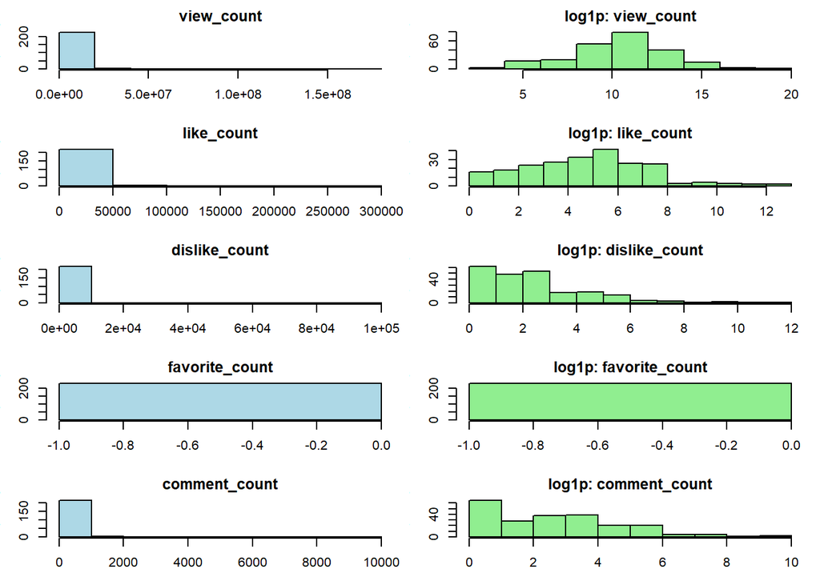

```r
par(mfrow = c(5, 2), mar = c(3, 3, 2, 1))

for (v in outcomes) {
  values <- youtube_clean[[v]]
  values <- values[!is.na(values)]

  hist(values, main = v, xlab = "Original count", col = "lightblue")
  hist(log1p(values), main = paste("log1p:", v),
       xlab = "log(1 + count)", col = "lightgreen")
}
```

```r
par(mfrow = c(1, 1))
```

View, like, dislike, and comment counts are strongly right-skewed, with means much larger than their medians. These four variables fall into category 2, so log(1 + count) is used to reduce skewness while keeping observations with zero counts. The transformed distributions are less skewed, although dislike and comment counts still show some right skew.

Favorite count falls into category 3 because all observed values are zero. Without variation, it is not a useful regression outcome. None of the five variables is selected for use as an untransformed outcome.

```r
usable_outcomes <- c(
  "view_count", "like_count", "dislike_count", "comment_count"
)

for (v in usable_outcomes) {
  youtube_clean[[paste0("log_", v)]] <- log1p(youtube_clean[[v]])
}
```

### (c) Linear regression models

```r
characteristics <- c(
  "funny", "show_product_quickly", "patriotic",
  "celebrity", "danger", "animals", "use_sex"
)

# Regress a log-transformed outcome on one characteristic and year.
# Inputs: outcome and characteristic names.
# Output: coefficient, p-value, and sample size.
fit_one_model <- function(outcome, characteristic) {
  d <- data.frame(
    response = youtube_clean[[paste0("log_", outcome)]],
    characteristic = as.integer(youtube_clean[[characteristic]]),
    year = youtube_clean$year
  )

  fit <- lm(response ~ characteristic + year, data = d)
  estimates <- summary(fit)$coefficients

  data.frame(
    outcome = outcome,
    characteristic = characteristic,
    coefficient = estimates["characteristic", "Estimate"],
    p_value = estimates["characteristic", "Pr(>|t|)"],
    n = nobs(fit)
  )
}

regression_results <- do.call(rbind, lapply(
  usable_outcomes, function(outcome) {
    do.call(rbind, lapply(characteristics, function(characteristic) {
      fit_one_model(outcome, characteristic)
    }))
  }
))

knitr::kable(regression_results, digits = 4, row.names = FALSE)
```

| outcome | characteristic | coefficient | p_value | n |
| --- | --- | --- | --- | --- |
| view_count | funny | 0.5298 | 0.2051 | 231 |
| view_count | show_product_quickly | 0.2090 | 0.6007 | 231 |
| view_count | patriotic | 0.1369 | 0.7839 | 231 |
| view_count | celebrity | -0.0190 | 0.9629 | 231 |
| view_count | danger | 0.6668 | 0.0941 | 231 |
| view_count | animals | -0.1733 | 0.6467 | 231 |
| view_count | use_sex | -0.2963 | 0.4905 | 231 |
| like_count | funny | 0.3602 | 0.3401 | 225 |
| like_count | show_product_quickly | 0.1683 | 0.6405 | 225 |
| like_count | patriotic | 0.4931 | 0.2897 | 225 |
| like_count | celebrity | 0.2630 | 0.4779 | 225 |
| like_count | danger | 0.6253 | 0.0803 | 225 |
| like_count | animals | 0.0246 | 0.9428 | 225 |
| like_count | use_sex | -0.3250 | 0.4001 | 225 |
| dislike_count | funny | 0.0415 | 0.8958 | 225 |
| dislike_count | show_product_quickly | 0.2429 | 0.4210 | 225 |
| dislike_count | patriotic | 0.6697 | 0.0856 | 225 |
| dislike_count | celebrity | -0.2833 | 0.3616 | 225 |
| dislike_count | danger | 0.1851 | 0.5379 | 225 |
| dislike_count | animals | -0.0738 | 0.7974 | 225 |
| dislike_count | use_sex | -0.3889 | 0.2293 | 225 |
| comment_count | funny | 0.0475 | 0.8793 | 222 |
| comment_count | show_product_quickly | 0.3460 | 0.2469 | 222 |
| comment_count | patriotic | 0.5148 | 0.1685 | 222 |
| comment_count | celebrity | 0.2281 | 0.4556 | 222 |
| comment_count | danger | 0.1064 | 0.7210 | 222 |
| comment_count | animals | -0.1918 | 0.4991 | 222 |
| comment_count | use_sex | -0.3494 | 0.2735 | 222 |

```r
significant_results <- subset(regression_results, p_value < 0.05)
significant_results$direction <- ifelse(
  significant_results$coefficient > 0, "Positive", "Negative"
)

knitr::kable(
  significant_results,
  digits = 4,
  row.names = FALSE,
  caption = "Significant associations at alpha = 0.05"
)
```

Significant associations at alpha = 0.05

| outcome | characteristic | coefficient | p_value | n | direction |
| --- | --- | --- | --- | --- | --- |

```r
view_results <- subset(regression_results, outcome == "view_count")

view_results[which.max(view_results$coefficient), ]
```

```
     outcome characteristic coefficient    p_value   n
5 view_count         danger   0.6667808 0.09406479 231
```

After adjusting for year, none of the seven commercial characteristics has a statistically significant association with any of the four log-transformed engagement outcomes at the 0.05 level. All p-values are above 0.05, so there are no significant positive or negative associations to report. Danger has the largest positive estimated association with log-transformed view count, with a coefficient of 0.6668. However, its p-value of 0.0941 is still above 0.05, so this association is not statistically significant.

### (d) Regression coefficients using matrix algebra

```r
selected_characteristic <- view_results$characteristic[
  which.min(view_results$p_value)
]
selected_characteristic
```

```
[1] "danger"
```

```r
d <- data.frame(
  response = youtube_clean$log_view_count,
  characteristic = as.integer(
    youtube_clean[[selected_characteristic]]
  ),
  year = youtube_clean$year
)

d <- d[complete.cases(d), ]

X <- cbind(
  Intercept = 1,
  characteristic = d$characteristic,
  year = d$year
)
y <- d$response

beta_matrix <- drop(
  solve(crossprod(X), crossprod(X, y))
)

fit_check <- lm(response ~ characteristic + year, data = d)

comparison <- data.frame(
  term = colnames(X),
  matrix_estimate = unname(beta_matrix),
  lm_estimate = unname(coef(fit_check)),
  difference = unname(beta_matrix - coef(fit_check))
)

knitr::kable(comparison, digits = 8, row.names = FALSE)
```

| term | matrix_estimate | lm_estimate | difference |
| --- | --- | --- | --- |
| Intercept | -31.39149243 | -31.39149243 | 0 |
| characteristic | 0.66678076 | 0.66678076 | 0 |
| year | 0.02065641 | 0.02065641 | 0 |

```r
isTRUE(all.equal(
  unname(beta_matrix),
  unname(coef(fit_check)),
  tolerance = 1e-6
))
```

```
[1] TRUE
```

Danger is selected because it has the smallest p-value among the models for log-transformed view count. The design matrix contains an intercept, the danger indicator, and year. The matrix method gives coefficients of −31.3915, 0.6668, and 0.0207, respectively. These match the estimates from lm() up to numerical precision, as confirmed by all.equal() returning TRUE.

## Sources and assistance

- Assignment: https://phuongov.github.io/stats506-f26/Homework%202/hw2.html
- YouTube commercials data: https://github.com/rfordatascience/tidytuesday/tree/main/data/2021/2021-03-02
- OpenAI Codex assisted with drafting part of R code, debugging, and reviewing outputs.